# QAA Report

### 9/15/2023

# Objective

The objective for the assignment was to perform analysis of RNA-seq data using existing tools such as fastqc, cutadapt, trimmomatic, and htseq as well as scripts from Bi621. This analysis included adapter trimming and quality assessment of resulting data. The reference genome in this analysis was the common House Mouse (*Mus Musculus*) and the paired sequences handled were:

**16_3D_mbnl_S12_L008_R1_001.fastq.gz**  
**16_3D_mbnl_S12_L008_R2_001.fastq.gz**  
**4_2C_mbnl_S4_L008_R1_001.fastq.gz**  
**4_2C_mbnl_S4_L008_R2_001.fastq.gz**

# Part 1

**FastQC Plotting**

First I ran FastQC on all four of my RNA-seq files. FastQC is a quality control tool used for quick analysis of sequence data from high-throughput pipelines used to form an impression of the data and decide whether it is fit for further analysis. The graphs included below are from the html files produced by FastQC on each sequence data.

Figures 1,3,5, and 7 are quality score plots generated from each library using FastQC. In general, the quality scores of all libraries remained above 30 (using phredscore33 encoding). A quality score of 30 corresponds to a call accuracy of 99.9% and is a benchmark for quality in next-gen sequencing. As such, these plots indicate data sufficient for analysis. Further supporting this point, FastQC generated plots of the per-base N content with findings consistent to that of the quality score plots depicted in figures 2,4,6, and 8.

Note: The beginning of all four reads start with relatively low quality scores when compared to the middle of the reads. However, this is a common occurrence in RNA-seq. The quality scores of the library similarly trail off when approaching the tail end of the library sequence. This is caused by several factors, one of which is the degradation of flourophores and polymerases also known as signal decay. Another cause of this drop in quality is the failure of nucleotide incorporation also known as phasing.

Note 2: I used a custom python script to generate quality score plots alongside of FastQC. I used the output of these scripts as a comparison tool. These graphs were less detailed and took longer to run. However, they showed the same shape and distribution of quality scores of FastQC giving me confidence in the attained results. I did not consider these plots fit for this report considering they provided sub-optimal information regarding the quality scores of the libraries.

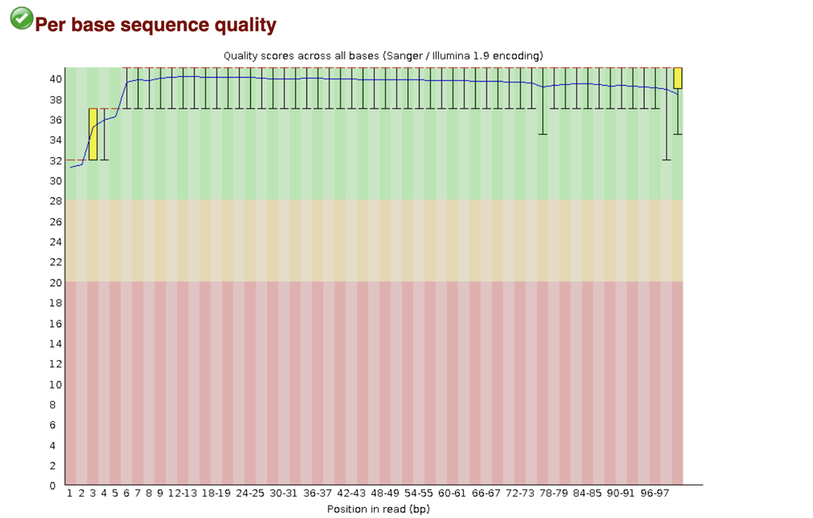

Figure 1: Quality Score plot of 16_3D_mbnl_S12_L008_R1_001 Read 1.

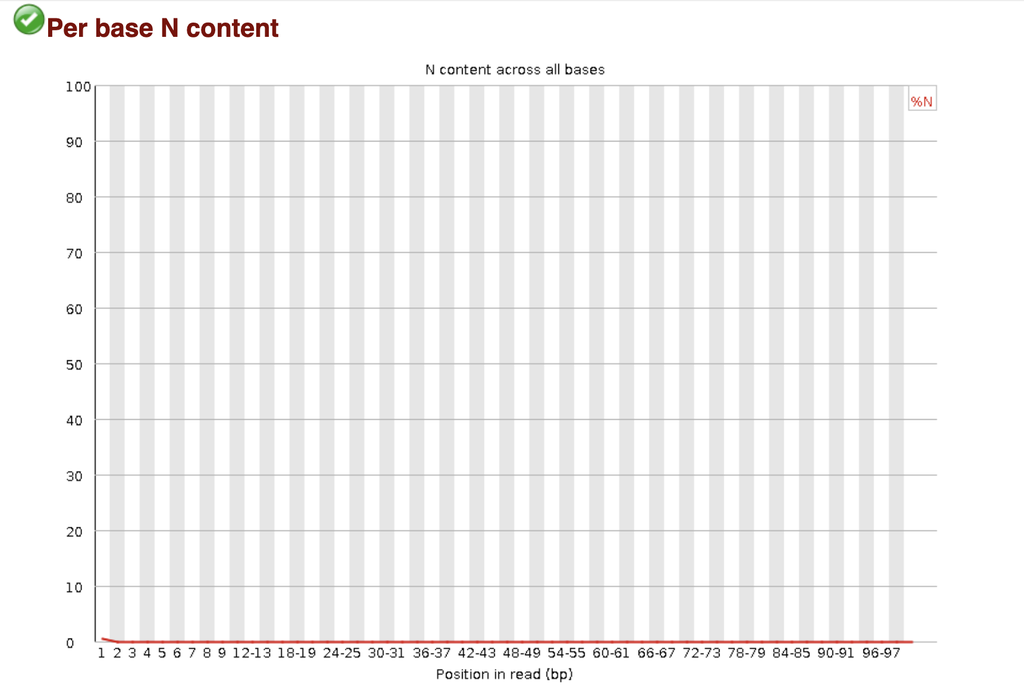

Figure 2: Per Base N Content 16_3D_mbnl_S12_L008_R1_001 Read 1.

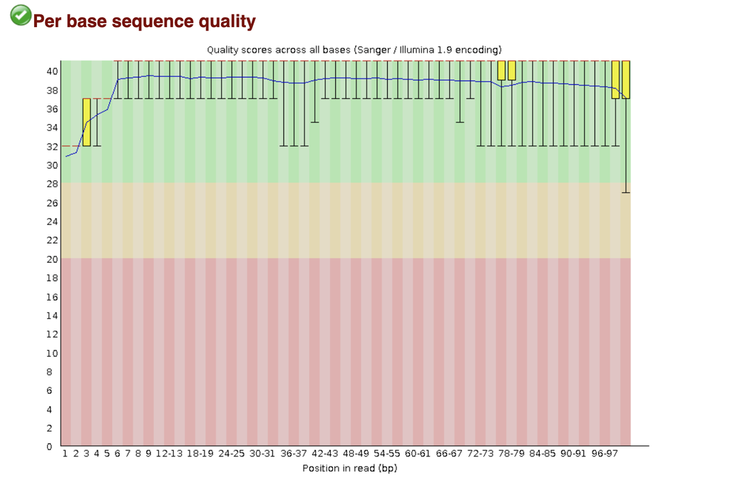

Figure 3: Quality Score plot of 16_3D_mbnl_S12_L008_R2_001 Read 2.

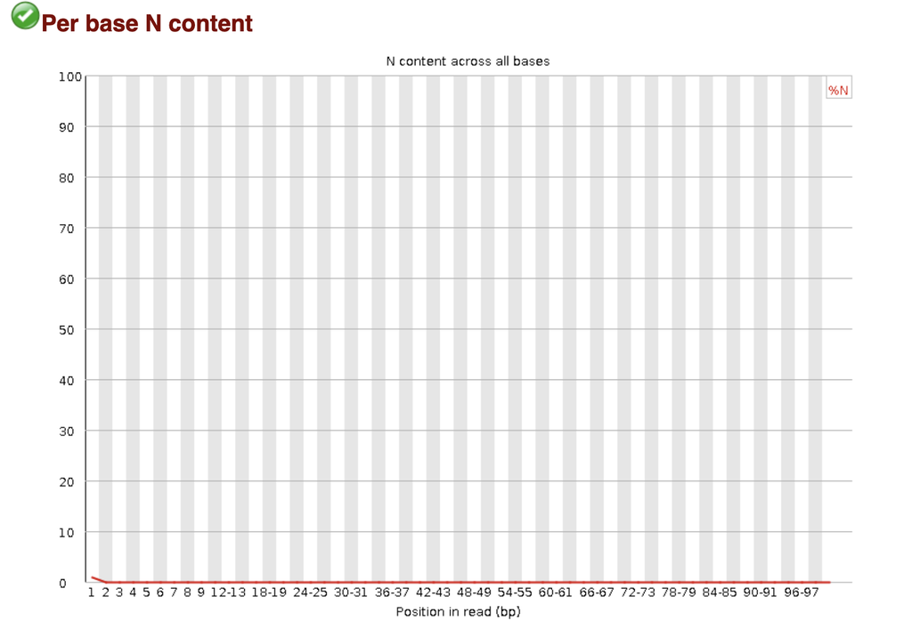

Figure 4: Per Base N Content 16_3D_mbnl_S12_L008_R2_001 Read 2.

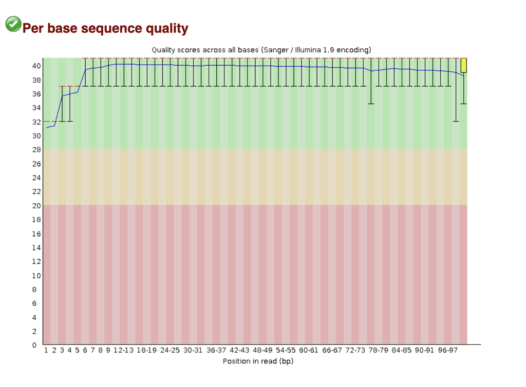

Figure 5: Quality Score plot of 4_2C_mbnl_S4_L008_R1_001 Read 1.

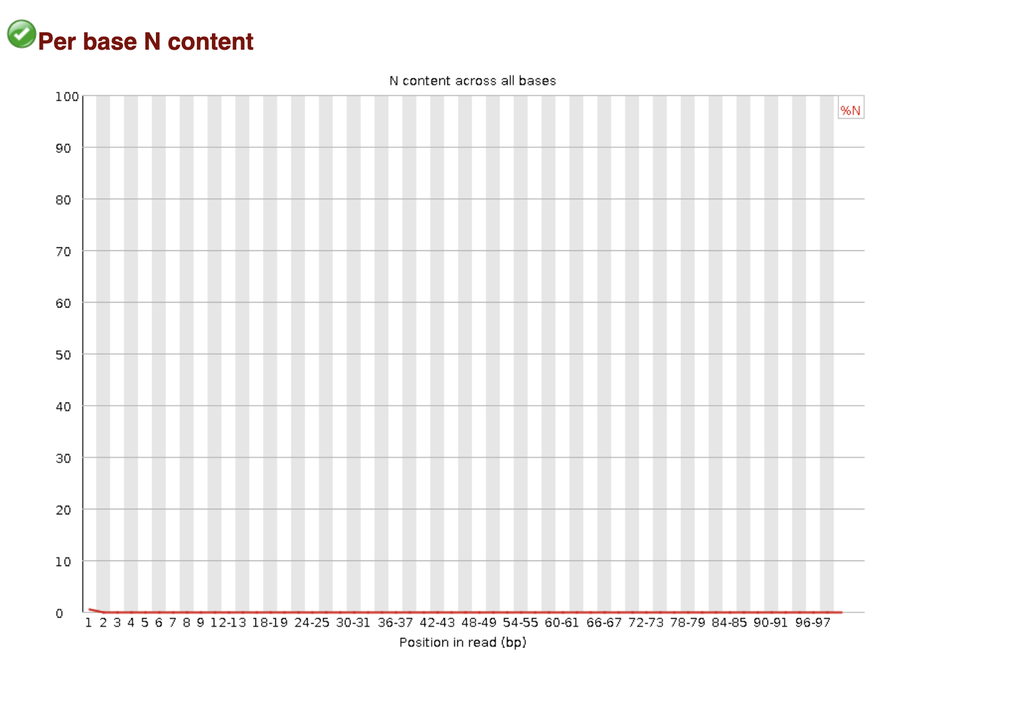

Figure 6: Per Base N Content 4_2C_mbnl_S4_L008_R1_001 Read 1.

[figure not shown]

Figure 7: Quality Score plot of 4_2C_mbnl_S4_L008_R2_001 Read 2.

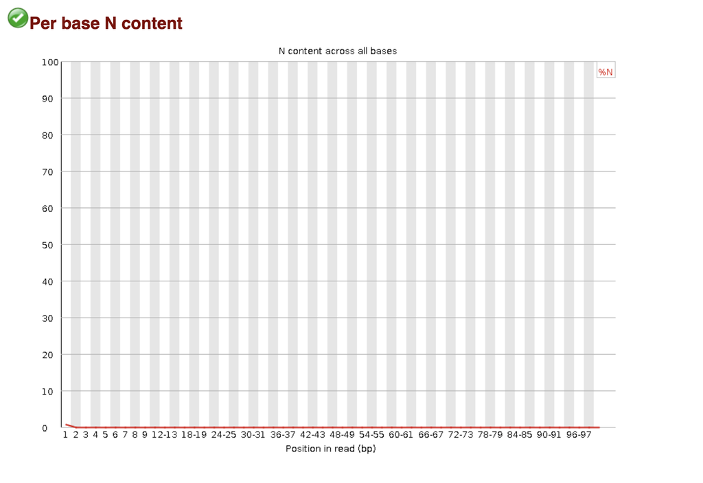

Figure 8: Per Base N Content 4_2C_mbnl_S4_L008_R2_001 Read 2.

# **Part 2**

**Trimming Sequences**

The next step was to trim the sequences according to quality score. First, I installed cutadapt v4.4 and trimmomatic v0.39 into my conda environment. The adapter sequences for cutadapt were provided. I used “-a AGATCGGAAGAGCACACGTCTGAACTCCAGTCA -A GATCGGAAGAGCGTCGTGTAGGGAAAGAGTGT”. Cutadapt on both sequences of data. The output below provided data on the processing of read pairs and trimming information below

**Cutadapt Output**:  
**16_3D_mbnl_S12_L008**  
Read 1 with adapter: 1,002,983 (12.2%)-  
Read 2 with adapter: 927,085 (11.3%)-  
**4_2C_mbnl_S4_L008**  
Read 1 with adapter: 570,274 (6.2%)-  
Read 2 with adapter: 510,886 (5.5%)-

Next, I ran trimmomatic using the “PE” parameter and “phredd33” parameter with a sliding window of 5:15, a minimum length of 35, leading set to 3, and trailing set to 3. This allowed me to generate two plots in excel demonstrating the trim rates of R1 and R2 for the two paired library.

**Length Distribution Plots**

Figures 9-10 are read length distribution plots per library pair (forward and reverse reads). The data was generated using cutadapt and trimmomatic. The data was then plotted via excel.

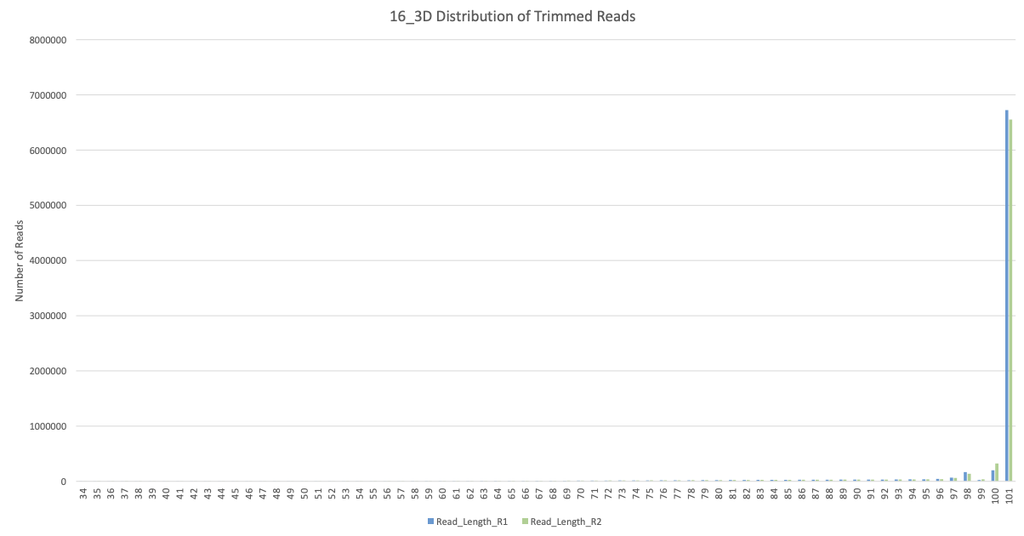

Figure 9: Length Distribution plot of 16_3D_mbnl_S12_L008 read 1 and 2.

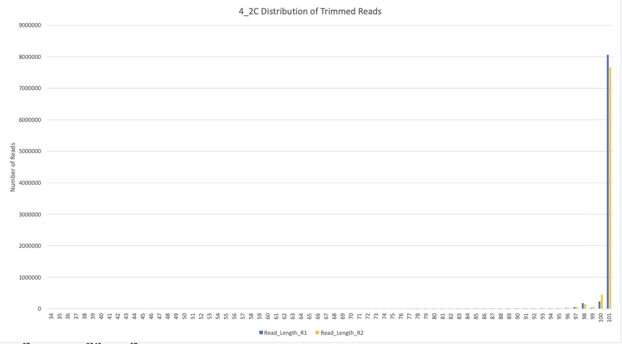

Figure 10: Length Distribution plot of 4_2C_mbnl_S4_L008 read 1 and 2.

The plots show that Read 2 lengths (reverse) tend to have shorter reads, which is a result of signal decay and reagent degradation. As such, the reverse reads were trimmed more as pictured.

# **Part 3**

**Mapping and Strandedness**

I installed HTSeq to count reads that map to features and specified in the parameters whether it was stranded or unstranded using the parameters: *–stranded=yes*, and *–stranded=reverse* respectively. Every other parameter was left to default. These tsv files that were output are stored in the “htseq” folder in my github repo. Using this bash command: **grep -v “^__” Aligned_reverse_16_3D_out.tsv | awk ‘$2>0 {sum+=$2} END {print sum}’** on each tsv file. I found that 84.04% of reads were on the reverse strand for 16_3D_mbnl_S12_L008 and 80.04% of reads were on the reverse strand for 4_2C_mbnl_S4_L008. This separation of percentage of reads mapped to reverse and regular strands in both cases indicates strandedness. If mapped reads were evenly distributed between forward and reverse reads the library could be concluded to be unstranded.